# TA1: Workflow in empirical research

## Expected Outcome

- How to think about the empirical aspect of research?
- How to organize empirical workflow?
- What is the most appropriate coding language for my project?
- What are the descriptives telling me?
- Is a regression the best idea?
- How do the results change when introducing fixed effects?

Download TA1 Code

## How to think about the empirical aspect of research

Empirical research is not “running regressions.” It is **building a credible bridge from variation in the world to a precise claim**, and making that bridge strong enough to survive a skeptical referee.

### 1) Start with an estimand, not a specification

Before code, write down the object you want to study:

- **Causal estimand:** the effect of (X) on (Y) (under a clearly stated intervention).
- **Descriptive estimand:** how (X) and (Y) co-move (useful, but not causal).
- **Predictive estimand:** forecasting (Y) (rarely the main goal in this course).

A regression is one possible estimator. The estimand is the research.

### 2) Identification is a story about variation

The core question is always:

> **Which variation identifies your claim?**

In practice:

- What moves your “treatment” variable?
- Why is that movement plausibly unrelated to the outcome except through your channel?
- What would break this argument?

If you cannot answer these three, you do not have an empirical design yet.

### 3) Assumptions are the price you pay for inference

Every design buys inference by paying assumptions. Your job is to:

- **minimize** the assumptions,
- **state** them clearly,
- **test** their implications wherever possible.

For example, fixed effects do not “solve endogeneity.” They change the comparison!

### 4) Data construction is part of the design

In corporate finance, many results are driven by measurement and sample choices:

- definitions (capital, liquidity, lending),
- winsorization and missing data rules,
- the sample pipeline (who enters, who exits, mergers, breakpoints).

A credible workflow produces:

- a transparent construction pipeline,
- a variable dictionary,
- a one-command replication script.

### 5) Estimation and inference are engineering

Once the design is clear, implementation must be correct:

- fixed effects reflect the comparison you want,
- clustering reflects the correlation structure of shocks,
- robustness checks target *specific threats*, not a grab bag of controls.

**Code is not decoration:** it is the proof that you estimated what you claimed.

### 6) Interpretation is economic, not statistical

“Significant” is not the endpoint.

Translate coefficients into:

- units that matter (percent, bps, dollars),
- plausible mechanisms,
- magnitudes relative to benchmarks.

If you cannot explain a coefficient in one sentence, the design is not finished.

### Referee-mode checklist (use this every time)

You are ready to show results only if you can answer:

1. What is the claim / estimand?
2. What variation identifies it?
3. Which assumption does the heavy lifting?
4. What diagnostic would convince you that you are wrong?

## How to organize empirical workflow

A good empirical workflow is not “clean data → run regressions.” It is a **repeatable pipeline** that turns raw inputs into claims, with enough structure that (i) you can debug, (ii) you can extend, and (iii) someone else can replicate.

### The principle: one button replication

Your project should have a single entry point:

- `run_all.R` rebuilds everything from scratch (data → tables/figures → site).
- If `run_all.R` breaks, the project is not yet research-grade.

### Recommended project structure

Use a consistent folder layout:

- `data_raw/` — original inputs (never edited by hand)
- `data_clean/` — cleaned intermediate data (created by scripts)
- `code/` — scripts (numbered in execution order)
- `output/tables/` — exported tables (CSV/LaTeX)
- `output/figures/` — exported figures (PNG/PDF)
- `docs/` — rendered site (GitHub Pages target)
- `scratch/` — temporary experiments (safe to delete)

Rule: **only `data_raw/` is “source of truth.”** Everything else is reproducible output.

### The pipeline (design → data → estimation → reporting)

Organize scripts as a sequence:

1. **00_setup.R**  
   load packages, set paths, set seed, define global options
2. **01_build_data.R**  
   read raw inputs, clean, construct variables, write `data_clean/master_panel.csv`
3. **02_descriptives.R**  
   sample checks, missingness, summary tables, baseline plots
4. **03_estimation.R**  
   main specifications, inference choices (FE, clustering), robustness targeted to threats
5. **04_outputs.R**  
   export model tables, export figures, save objects needed by the site
6. **05_render.R**  
   render the website / report

This is exactly how you keep analysis modular and debuggable.

### “Logs” you should always produce

Every serious empirical project prints (and saves) the answers to:

- What is the sample size at each filter step?
- How many unique units (banks / firms) and time periods?
- Are there duplicates in the panel key?
- What is missing, and is it systematic?
- What is the distribution of key variables (levels and changes)?

If you do not log these, you will waste days later.

### Version control is part of the workflow

A clean Git routine:

- commit after each meaningful, working change
- commit messages describe *what changed and why*
- keep large derived files out of Git (use `.gitignore` for `data_clean/` if needed)
- tag stable versions (e.g., `v1_ta1_complete`) so you can always revert

### Dependency management (avoid “it works on my machine”)

Do not install packages inside scripts.

- use `renv` (or equivalent) to lock package versions
- record session info at the end of runs (`sessionInfo()`)

### The TA1 standard

In TA1, the workflow goal is:

> Build a synthetic master panel once, then repeatedly reuse it for descriptives and fixed-effects models.

By TA2–TA6, you should still be using the same pipeline — you just add modules and extend the master dataset.

## What is the most appropriate coding language for my project?

The “best” language is the one that minimizes total research cost: **time to implement + time to debug + time to replicate + credibility with your audience**.

### Quick positioning

- **Stata**: best for *standard applied micro workflows* and fast, conventional regression work; weakest for modern software engineering and large-scale data pipelines.
- **R**: best all-around for *econometrics + visualization + reproducible reporting*; strong for high-dimensional fixed effects and modern causal packages.
- **Python**: best for *data engineering, web scraping, APIs, text/NLP, and scalable pipelines*; econometrics is good but reporting and some “applied micro conventions” can be more work than in Stata/R.
- **Gretl**: great teaching tool and lightweight econometrics; less common in top-tier research workflows and ecosystem is smaller.
- **Matlab**: excellent for *numerical methods, simulations, structural models, optimization*; not the default for reduced-form empirical pipelines (data cleaning + causal inference + reporting).

### What each one is “for” in practice

#### **Stata**

- you want the quickest path from cleaned panel → conventional tables,
- you are following a classic applied micro/corp-fin template,
- your coauthors/advisors are Stata-native.

Watch-outs: less natural for reproducible research engineering (project pipelines, dependency mgmt), more friction for scraping, APIs, and complex text processing.

#### **R**

- you want **research-grade reporting** (Quarto/Rmd) + clean figures + tables,
- you need **high-dimensional fixed effects** and modern causal inference tooling,
- you want to teach / enforce a transparent workflow (scripts + outputs + site).

Watch-outs:

- some data engineering tasks are easier in Python (scraping, messy parsing),
- performance can require care for very large datasets.

#### **Python**

- you need web scraping, APIs, NLP, and messy data ingestion,
- you want a scalable pipeline mindset (testing, automation),
- you’re building datasets more than running canned regressions.

Watch-outs:

- for “applied micro style” regression tables and FE-heavy work, you may do more manual setup than in R/Stata,
- the ecosystem is broader, so conventions vary more across labs.

#### **Gretl**

- you want a simple environment for classic econometrics and teaching,
- you need something lightweight and transparent for small projects.

Watch-outs:

- much smaller ecosystem; less common in corp-fin research replication packages,
- fewer cutting-edge methods implemented as quickly as R/Stata.

#### **Matlab**

- you are doing **structural estimation**, numerical optimization, simulations, dynamic programming,
- you need high-quality linear algebra tools and controlled numerical workflows.

Watch-outs:

- not the easiest default for data cleaning + causal inference + reproducible reporting,
- fewer “applied micro defaults” than Stata/R.

### A good rule for this course

For Finance 4 empirical TA work, the lowest-friction, highest-credibility stack is:

- **R as the main analysis language** (econometrics + reporting + figures)
- **Git for version control**
- **Python as an add-on** when we move to web scraping / text (later topics)

If you personally live in Stata, a perfectly fine alternative is:

- **Stata for estimation + core tables**, plus
- **Python** (or R) for scraping and data construction, and
- still **Git** for version control.

### The only “wrong” choice

Mixing languages without clear boundaries.

Good mixes:

- Python → R (Python builds data, R estimates/reports)
- Python → Stata (Python builds data, Stata estimates/tables)
- SQL → (R/Stata/Python) (SQL builds analysis tables)

Bad mix:

- switching languages mid-analysis for the same task (harder to replicate, harder to debug, harder to teach).

## Time to Code!

We will use:

- `code/00_utils.R`
- `code/01_build_teaching_data.R`
- `code/02_ta1_fixed_effects.R`

### Data

TA1 uses a synthetic banking panel so everyone can run the full workflow locally without proprietary access, with:

- one observation per bank-year,
- balance-sheet variables such as assets, capital, liquidity, and lending growth,
- threshold treatment based on bank size.

### Core Idea

Fixed effects are not a magic solution to endogeneity. They answer a different question:

- pooled OLS compares different banks to one another,
- bank fixed effects compare a bank to itself over time,
- year fixed effects purge common aggregate shocks.

### Intuition

When we study lending, we usually do **not** observe pure credit supply. Loan growth reflects:

- bank willingness to lend,
- borrower demand for credit,
- common macro conditions,
- local shocks in the places where the bank operates.

### Main script

```r
fe_model <- fixest::feols(
  loan_growth ~ capital_ratio + liquidity_ratio + treated | bank_id + year,
  cluster = ~bank_id,
  data = bank_panel
)
```

### Descriptive statistics

```r
ta1_desc <- readr::read_csv("output/tables/ta1_descriptives.csv", show_col_types = FALSE) |>
  dplyr::mutate(dplyr::across(where(is.numeric), ~round(.x, 3)))

knitr::kable(ta1_desc, caption = "Selected descriptives from the master bank panel")
```

Selected descriptives from the master bank panel

| variable | mean | sd | p25 | median | p75 |
| --- | --- | --- | --- | --- | --- |
| assets_bn | 13.894 | 6.457 | 9.266 | 12.560 | 17.018 |
| capital_ratio | 0.114 | 0.015 | 0.104 | 0.114 | 0.125 |
| chargeoff_rate | 0.025 | 0.006 | 0.021 | 0.025 | 0.029 |
| liquidity_ratio | 0.176 | 0.035 | 0.155 | 0.175 | 0.196 |
| loan_growth | 0.061 | 0.076 | 0.024 | 0.070 | 0.112 |
| roa | 0.011 | 0.005 | 0.008 | 0.012 | 0.015 |
| small_business_share | 0.228 | 0.023 | 0.212 | 0.226 | 0.244 |

### Main regression output

```r
ta1_models <- readr::read_csv("output/tables/ta1_model_table.csv", show_col_types = FALSE) |>
  dplyr::filter(term != "(Intercept)") |>
  dplyr::select(model, term, estimate, std.error, statistic, p.value) |>
  dplyr::mutate(dplyr::across(c(estimate, std.error, statistic, p.value), ~round(.x, 3)))

knitr::kable(ta1_models, caption = "Pooled and fixed-effects estimates")
```

Pooled and fixed-effects estimates

| model | term | estimate | std.error | statistic | p.value |
| --- | --- | --- | --- | --- | --- |
| Pooled OLS | capital_ratio | 1.630 | 0.225 | 7.233 | 0.000 |
| Pooled OLS | liquidity_ratio | 0.322 | 0.119 | 2.698 | 0.009 |
| Pooled OLS | treated | -0.004 | 0.007 | -0.569 | 0.571 |
| Bank FE + Year FE | capital_ratio | 0.802 | 0.156 | 5.131 | 0.000 |
| Bank FE + Year FE | liquidity_ratio | 0.145 | 0.130 | 1.116 | 0.268 |
| Bank FE + Year FE | treated | 0.000 | 0.003 | -0.125 | 0.901 |

### Visual summary

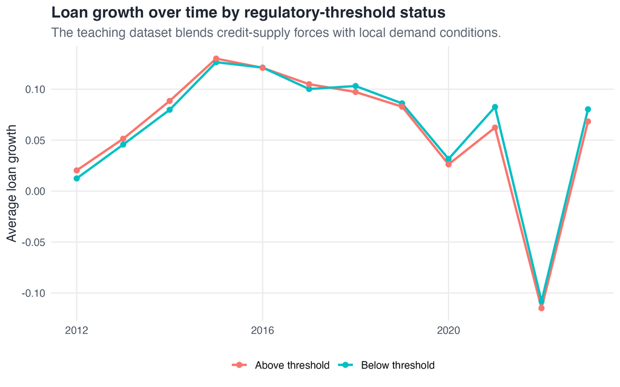